# Sta112FS 14. More on functions + Bootstrapping

Dr. Çetinkaya-Rundel

October 22, 2015

# Today’s agenda

## Today’s agenda

- More on functions
- Bootstrapping
- **Due Tuesday:** Read Chapter 16 on Bootstrapping at http://content.bfwpub.com/webroot_pubcontent/Content/BCS_4/IPS7e/Student/Companion%20Chapters/ips_chap16.pdf

# Building a function

## Pseudo code

1. Check for potential errors
2. Load packages, clean data, set seed
3. Calculate sample statistics, using `data` and the level of the data defined as `success`
4. Simulate the null distribution, using sample size based on `data`, `null` value as the assumed true probability of `success`, and `nsim`
5. Calculate the p-value, as the proportion of simulations where the simulated probability of success is at least as extreme as the observed sample statistic calculated in item 3. Note that the definition of “extreme” will depend on the `alt`
6. Print/plot all desired output: hypotheses, summary statistics, p-value, plot of simulation distribution
7. Return p-value as function output

## Skeleton

```r
one_cat_test <- function(data, success, null, alt, nsim, seed, print_summ, print_plot){
  # code corresponding to steps outlined in pseudo code
}
```

## Set defaults for input arguments

```r
one_cat_test <- function(data, success = NULL, null = NULL, alt = "not equal",
                         nsim = 15000, seed = NULL, print_summ = TRUE, print_plot = TRUE){
  # code corresponding to steps outlined in pseudo code
}
```

## Step 1 - Check for potential errors

```r
one_cat_test <- function(data, success = NULL, null = NULL, alt = "not equal",
                         nsim = 15000, seed = NULL, print_summ = TRUE, print_plot = TRUE){
  ## check for errors ---------------------------##
  # check if ggplot2 is installed
  installed_packages = names(installed.packages()[,"Package"])
  if (!("ggplot2" %in% installed_packages)){
    stop("Install the ggplot2 package.")
  }

  # errors associated with null hypothesis
  if(null < 0 | null > 1 | !is.numeric(null)) {
    stop("Null value should be a numeric value between 0 and 1.")
  }
  if(is.null(null)) { stop("Missing null value.") }

  # errors associated with alternative hypothesis
  if(!(alt %in% c("greater", "less", "not equal"))) {
    stop("Alternative hypothesis not specified properly, should be less, greater, or not equal.")
  }

  # errors associated with data format
  if(is.null(data)) { stop("Missing data.") }
  if(is.data.frame(data)) { stop("Data should be a vector, not a data frame.") }
  # ...
}
```

## Step 2 - Load packages, clean data, set seed

```r
one_cat_test <- function(data, success = NULL, null = NULL, alt = "not equal",
                         nsim = 15000, seed = NULL, print_summ = TRUE, print_plot = TRUE){
  # ...

  ## setup --------------------------------------##

  # load ggplot2 quietly
  suppressMessages(library(ggplot2, quietly = TRUE))

  # remove NAs
  data = data[!is.na(data)]

  # set seed, if provided
  if(!is.null(seed)) { set.seed(seed) }

  # ...
}
```

## Step 3 - Calculate sample statistics

```r
one_cat_test <- function(data, success = NULL, null = NULL, alt = "not equal",
                         nsim = 15000, seed = NULL, print_summ = TRUE, print_plot = TRUE){
  # ...
  ## calculate sample statistics ----------------##

  # set sample size
  n = length(data)

  # calculate observed number of successes
  n_suc = sum(data == success)

  # set function for calculating proportion of successes
  calc_phat = function(x){ sum(x == success) / n }
  stat = calc_phat(data)

  # set outcomes to sample from
  outcomes = levels(as.factor(data))
  # error if data has more than 2 levels
  if(length(outcomes) > 2) { stop("Input data has more than two levels.") }

  # set probability with which to sample
  if(which(outcomes == success) == 1) { p = c(null, 1-null) }
  if(which(outcomes == success) == 2) { p = c(1-null, null) }

  # ...
}
```

## Step 4 - Simulate null distribution

```r
one_cat_test <- function(data, success = NULL, null = NULL, alt = "not equal",
                         nsim = 15000, seed = NULL, print_summ = TRUE, print_plot = TRUE){
  # ...

  ## simulate null distribution ------------------##

  null_dist = data.frame(stat = rep(NA, nsim))
  for(i in 1:nsim){
    sim_sample = sample(outcomes, size = n, prob = p, replace = TRUE)
    null_dist$stat[i] = calc_phat(sim_sample)
  }

  # ...
}
```

## Step 5 - Calculate p-value

```r
one_cat_test <- function(data, success = NULL, null = NULL, alt = "not equal",
                         nsim = 15000, seed = NULL, print_summ = TRUE, print_plot = TRUE){
  # ...
  ## calculate p-value ---------------------------##

  # calculate number of simulated p-hats at least as extreme as observed p-hat
  if(alt  == "greater"){ nsim_extreme = sum(null_dist$stat >= stat) }
  if(alt  == "less"){ nsim_extreme = sum(null_dist$stat <= stat) }
  if(alt  == "not equal"){
    if(stat > null) { nsim_extreme = 2 * sum(null_dist$stat >= stat) }
    if(stat < null) { nsim_extreme = 2 * sum(null_dist$stat <= stat) }
  }

  # calculate p-value
  p_value = nsim_extreme / nsim

  # ...
}
```

## Step 6a - Print summary

```r
one_cat_test <- function(data, success = NULL, null = NULL, alt = "not equal",
                         nsim = 15000, seed = NULL, print_summ = TRUE, print_plot = TRUE){
  # ...
  ## print summary ------------------------------##
  if(print_summ == TRUE){
    # print null hypothesis
    cat(paste("H0: p =", null, "\n"))

    # set alternative hypothesis sign
    if(alt == "not equal") { alt_sign = "!=" }
    if(alt == "greater") { alt_sign = ">" }
    if(alt == "less") { alt_sign = "<" }

    # print alternative hypothesis
    cat(paste("HA: p", alt_sign, null, "\n"))

    # print summary statistics
    cat(paste("Summary stats: n =", n, ", number of successes =", n_suc, ", p-hat =", round(stat, 4), "\n"))

    # print p-value
    if(round(p_value, 4) == 0) { cat(paste("p-value < 0.0001\n")) }
    if(round(p_value, 4) > 0) { cat(paste("p-value = ", round(p_value, 4), "\n")) }
  }

  # ...
}
```

## Step 6b - Plot null distribution

```r
one_cat_test <- function(data, success = NULL, null = NULL, alt = "not equal",
                         nsim = 15000, seed = NULL, print_summ = TRUE, print_plot = TRUE){
  # ...

  ## plot null distribution ---------------------##

  if(plot == TRUE){
    # dot plot if low number of simulations
    if(nsim <= 100){
      simdist_plot = ggplot(data = null_dist, aes(x = stat)) + geom_dotplot()
      suppressWarnings( suppressMessages( print( simdist_plot ) ) )
    }
    # histogram if high number of simulations
    if(nsim > 100){
      bw = (max(null_dist$stat) - min(null_dist$stat)) / 20
      simdist_plot = ggplot(data = null_dist, aes(x = stat)) + geom_histogram(binwidth = bw)
      suppressWarnings( suppressMessages( print( simdist_plot ) ) )
    }
  }

  # ...
}
```

## Step 7 - Return p-value

```r
one_cat_test <- function(data, success = NULL, null = NULL, alt = "not equal",
                         nsim = 15000, seed = NULL, print_summ = TRUE, print_plot = TRUE){
  # ...

  ## return -------------------------------------##
  return(invisible(list(p_value = p_value)))

}
```

## Load complete function and data

```r
source("https://stat.duke.edu/courses/Fall15/sta112.01/code/one_cat_test.R")
kissing <- read.csv("https://stat.duke.edu/~mc301/data/kissing.csv")
```

## Run my function, compare to yours

```r
one_cat_test(data = kissing$side, success = "right", null = 0.5, alt = "greater",
             seed = 10222015)
```

```
## H0: p = 0.5
## HA: p > 0.5
## Summary stats: n = 124 , number of successes = 80 , p-hat = 0.6452
## p-value =  9e-04
```

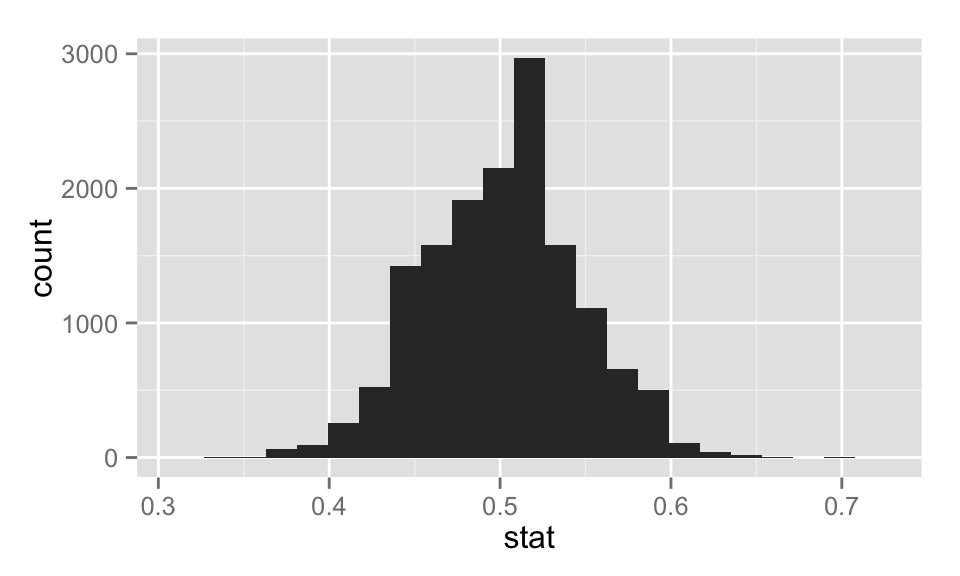

## Return

```r
mytest <- one_cat_test(data = kissing$side, success = "right",
                       null = 0.5, alt = "greater", seed = 10222015)
```

```
## H0: p = 0.5
## HA: p > 0.5
## Summary stats: n = 124 , number of successes = 80 , p-hat = 0.6452
## p-value =  9e-04
```

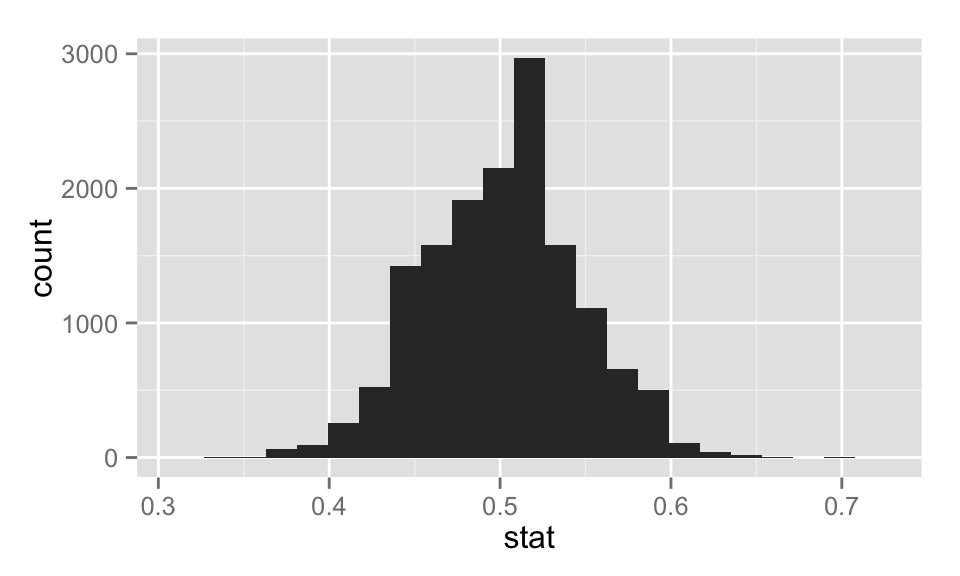

```r
mytest$p_value
```

```
## [1] 0.0009333333
```

# Confidence intervals via bootstrapping

## Confidence intervals

A plausible range of values for the population parameter is called a **confidence interval**.

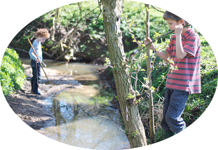

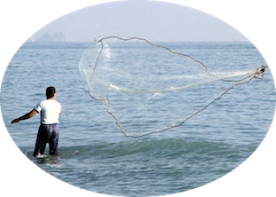

- If we report a point estimate, we probably won’t hit the exact population parameter.
- If we report a range of plausible values we have a good shot at capturing the parameter.

## Bootstrapping

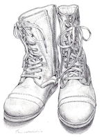

- One method of constructing a confidence interval, via simulation, is **bootstrapping**.
- This term comes from the phrase “pulling oneself up by one’s bootstraps”, which is a metaphor for accomplishing an impossible task without any outside help.
- In this case the impossible task is estimating a population parameter, and we’ll accomplish it using data from only the given sample.

## Bootstrapping scheme

1. Take a bootstrap sample - a random sample taken with replacement from the original sample, of the same size as the original sample
2. Calculate the bootstrap statistic - a statistic such as mean, median, proportion, etc. computed on the bootstrap samples
3. Repeat steps (1) and (2) many times to create a bootstrap distribution - a distribution of bootstrap statistics

## Bootstrapping in action

Let’s create the bootstrap distribution for the `kissing` dataset.

```r
set.seed(2345183)
nsim = 100
boot_dist = data.frame(stat = rep(NA, nsim))
for(i in 1:nsim){
  boot_sample = sample(kissing$side, size = 124, replace = TRUE)
  boot_dist$stat[i] = sum(boot_sample == "right") / 124
}
```

## Plotting the bootstrap distribution

What does each dot in the following plot represent?

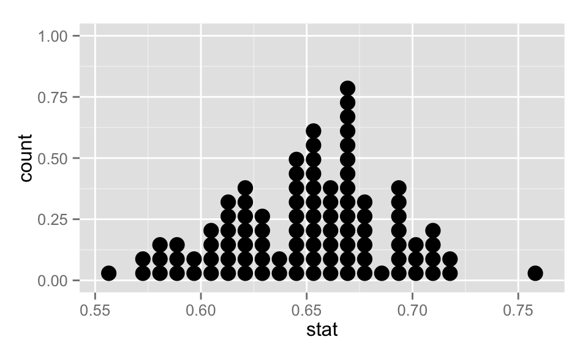

```r
ggplot(boot_dist, aes(x = stat)) +
  geom_dotplot()
```

## Shape of the bootstrap distribution

To make the shape a little easier to detect, let’s increase the number of simulations.

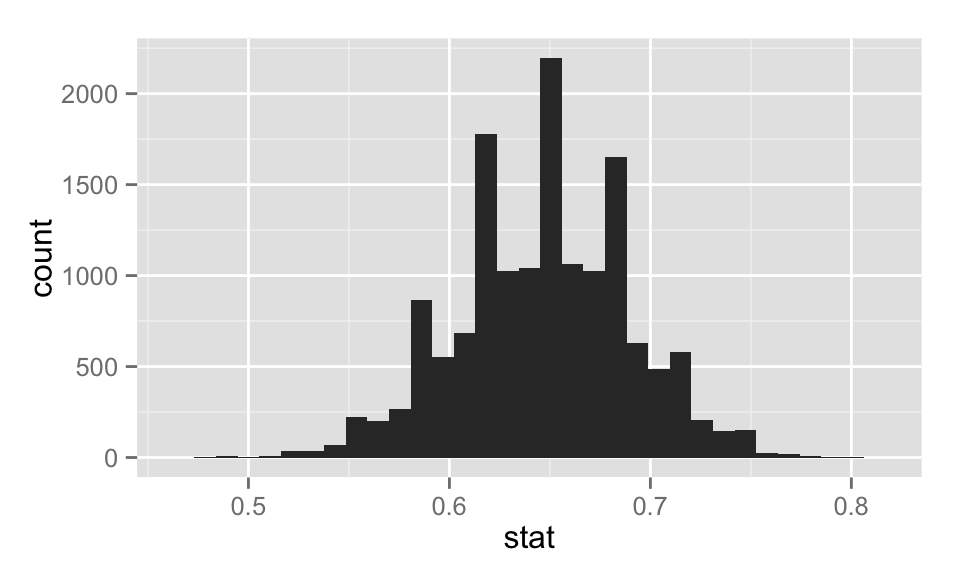

```r
nsim = 15000
boot_dist = data.frame(stat = rep(NA, nsim))
for(i in 1:nsim){
  boot_sample = sample(kissing$side, size = 124, replace = TRUE)
  boot_dist$stat[i] = sum(boot_sample == "right") / 124
}
ggplot(data = boot_dist, aes(x = stat)) +
  geom_histogram()
```

## The normal distribution, $N(\mu, \sigma)$

- Unimodal and symmetric (bell curve)
- Follows very strict guidelines about how variably the data are distributed around the mean many variables are nearly normal, but none are exactly normal

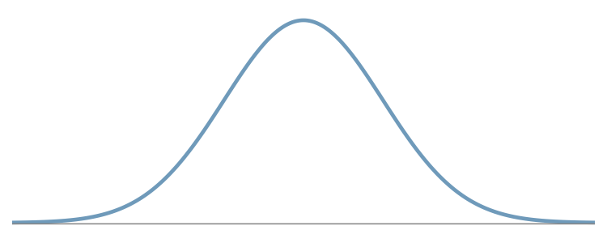

## 68-95-99.7% rule

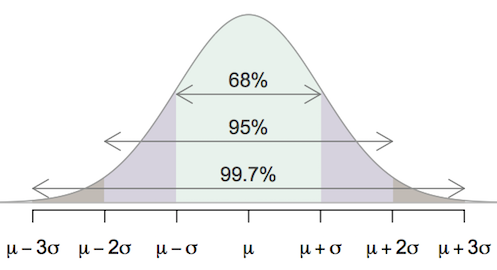

To be more exact:

```r
percentiles <- c(0.0015, 0.025, 0.16, 0.84, 0.975, 0.9985)
round(qnorm(percentiles), 2)
```

```
## [1] -2.97 -1.96 -0.99  0.99  1.96  2.97
```

## 95% bootstrap interval

The approximate 95% bootstrap confidence interval can be calculated as follows:

$$\hat{p} \pm 1.96 \times SE_{boot}$$

- $\hat{p}$: observed sample proportion
- $SE_{boot}$: variability (standard deviation) of the bootstrap distribution

**Standard error** is a term reserved for quantifying the variability of the sample statistic, as opposed to variability of individual observations, that is measured by the standard deviation.

## Calculating the 95% bootstrap interval

```r
stat = sum(kissing$side == "right") / 124
se_boot = sd(boot_dist$stat)
(boot_int = round(stat + c(-1,1) * 1.96 * se_boot, 4))
```

```
## [1] 0.5607 0.7296
```

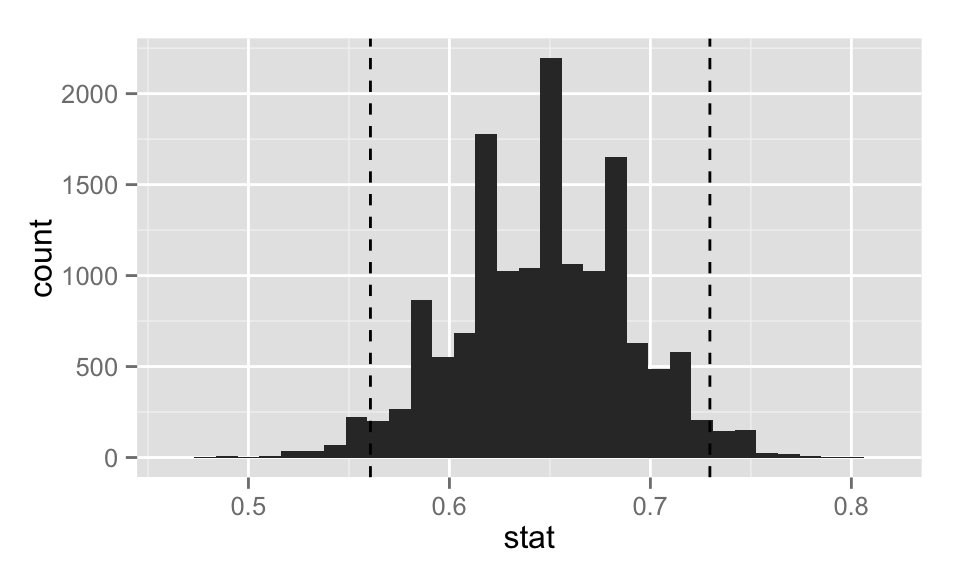

```r
ggplot(data = boot_dist, aes(x = stat)) +
  geom_histogram() +
  geom_vline(xintercept = boot_int, lty = 2)
```

**Interpretation:** We are 95% confident that 56% to 73% of couples turn to the right when kissing.